# BIA 6301 APPLIED DATA MINING HOMEWORK ASSIGNMENT 3

Leonardo Ji

2017-04-04

### Part A. Customer Segmentation at a Bakery

The purpose of this assignment is to show how k-means is used in customer segmentation analysis.

You are a newly minted data scientist who have decided to start a statistical consulting business. Your neighbor happens to be the owner of a local bakery called Cookie & Icing, and she has asked you to help her identify “customer base and additional sales opportunities.” The neighbor provides you with a data set named bakery-binary.csv, which contains 1,000 customer transactions and 51 attributes. Each transaction corresponds to item purchases made by the customer during a visit to Cookie & Icing. The items are 50 different cakes, pastries, coffee products, and beverages. A “1” in a transaction indicates the purchase of the corresponding item, and a 0 indicates no purchase for the item. An additional attribute named “Weekend” indicates whether the transaction took place on a weekend.

```
You decided to perform k-means cluster analysis on the provided data set and identified the following "k" (or clusters) to try out: 4, 5, 6, 7, and 8.
```

1. How many customer segments are prevalent in the provided data set after you have conducted the analysis? Justify your answer. Describe the characteristics of each customer segment. (Hint: You should generate aggregate profiles for the clusters and then sort the centroid values along with the item names in descending order. You may also want to filter out the items with very low centroid values. These tasks will make it easier to identify the characteristics of the customer segments.)
2. Is there a particular customer segment that primarily made purchases during the weekend? If yes, what were the popular items with the weekend customers?
3. Can you identify four to six potential opportunities for Cookie & Icing to increase sales of one or more of the products through cross-sell recommendations and/or other types of customer incentives? Justify your answer.

### Data

1000 rows of bineary Bakery customers’ purchase items data.

```r
setwd("C:/Users/lj015625/Desktop/DataMining Class/HW3/data")
bakery<-read.csv("bakery-binary.csv",header=TRUE, sep=",")
dim(bakery)
```

```
## [1] 1000   51
```

```r
names(bakery)
```

```
##  [1] "Chocolate.Cake"      "Lemon.Cake"          "Casino.Cake"
##  [4] "Opera.Cake"          "Strawberry.Cake"     "Truffle.Cake"
##  [7] "Chocolate.Eclair"    "Coffee.Eclair"       "Vanilla.Eclair"
## [10] "Napoleon.Cake"       "Almond.Tart"         "Apple.Pie"
## [13] "Apple.Tart"          "Apricot.Tart"        "Berry.Tart"
## [16] "Blackberry.Tart"     "Blueberry.Tart"      "Chocolate.Tart"
## [19] "Cherry.Tart"         "Lemon.Tart"          "Pecan.Tart"
## [22] "Ganache.Cookie"      "Gongolais.Cookie"    "Raspberry.Cookie"
## [25] "Lemon.Cookie"        "Chocolate.Meringue"  "Vanilla.Meringue"
## [28] "Marzipan.Cookie"     "Tuile.Cookie"        "Walnut.Cookie"
## [31] "Almond.Croissant"    "Apple.Croissant"     "Apricot.Croissant"
## [34] "Cheese.Croissant"    "Chocolate.Croissant" "Apricot.Danish"
## [37] "Apple.Danish"        "Almond.Twist"        "Almond.Bear.Claw"
## [40] "Blueberry.Danish"    "Lemon.Lemonade"      "Raspberry.Lemonade"
## [43] "Orange.Juice"        "Green.Tea"           "Bottled.Water"
## [46] "Hot.Coffee"          "Chocolate.Coffee"    "Vanilla.Frappuccino"
## [49] "Cherry.Soda"         "Single.Espresso"     "Weekend"
```

```r
str(bakery)
```

```
## 'data.frame':    1000 obs. of  51 variables:
##  $ Chocolate.Cake     : int  0 0 1 0 0 0 0 0 1 1 ...
##  $ Lemon.Cake         : int  0 0 0 0 0 0 0 0 0 0 ...
##  $ Casino.Cake        : int  0 0 0 1 1 0 0 0 0 1 ...
##  $ Opera.Cake         : int  0 1 0 0 0 0 1 1 0 0 ...
##  $ Strawberry.Cake    : int  0 0 1 0 0 0 0 0 0 0 ...
##  $ Truffle.Cake       : int  0 0 0 0 0 0 0 0 0 0 ...
##  $ Chocolate.Eclair   : int  0 0 0 1 0 0 0 1 0 0 ...
##  $ Coffee.Eclair      : int  0 0 0 0 0 0 0 0 0 0 ...
##  $ Vanilla.Eclair     : int  0 0 0 0 0 0 0 0 0 0 ...
##  $ Napoleon.Cake      : int  0 0 1 0 0 1 0 0 0 0 ...
##  $ Almond.Tart        : int  0 0 0 0 1 0 0 0 0 0 ...
##  $ Apple.Pie          : int  0 0 0 0 0 0 0 0 0 0 ...
##  $ Apple.Tart         : int  0 0 0 0 0 0 0 0 0 0 ...
##  $ Apricot.Tart       : int  0 0 0 0 0 0 0 1 0 0 ...
```

[output cut: 37 more lines]

```r
summary(bakery)
```

```
##  Chocolate.Cake    Lemon.Cake     Casino.Cake      Opera.Cake
##  Min.   :0.000   Min.   :0.000   Min.   :0.000   Min.   :0.000
##  1st Qu.:0.000   1st Qu.:0.000   1st Qu.:0.000   1st Qu.:0.000
##  Median :0.000   Median :0.000   Median :0.000   Median :0.000
##  Mean   :0.084   Mean   :0.085   Mean   :0.072   Mean   :0.078
##  3rd Qu.:0.000   3rd Qu.:0.000   3rd Qu.:0.000   3rd Qu.:0.000
##  Max.   :1.000   Max.   :1.000   Max.   :1.000   Max.   :1.000
##  Strawberry.Cake  Truffle.Cake   Chocolate.Eclair Coffee.Eclair
##  Min.   :0.000   Min.   :0.000   Min.   :0.000    Min.   :0.000
##  1st Qu.:0.000   1st Qu.:0.000   1st Qu.:0.000    1st Qu.:0.000
##  Median :0.000   Median :0.000   Median :0.000    Median :0.000
##  Mean   :0.091   Mean   :0.103   Mean   :0.034    Mean   :0.093
##  3rd Qu.:0.000   3rd Qu.:0.000   3rd Qu.:0.000    3rd Qu.:0.000
##  Max.   :1.000   Max.   :1.000   Max.   :1.000    Max.   :1.000
##  Vanilla.Eclair  Napoleon.Cake   Almond.Tart      Apple.Pie
##  Min.   :0.000   Min.   :0.00   Min.   :0.000   Min.   :0.000
##  1st Qu.:0.000   1st Qu.:0.00   1st Qu.:0.000   1st Qu.:0.000
##  Median :0.000   Median :0.00   Median :0.000   Median :0.000
##  Mean   :0.037   Mean   :0.09   Mean   :0.041   Mean   :0.068
##  3rd Qu.:0.000   3rd Qu.:0.00   3rd Qu.:0.000   3rd Qu.:0.000
##  Max.   :1.000   Max.   :1.00   Max.   :1.000   Max.   :1.000
##    Apple.Tart     Apricot.Tart     Berry.Tart    Blackberry.Tart
##  Min.   :0.000   Min.   :0.000   Min.   :0.000   Min.   :0.000
##  1st Qu.:0.000   1st Qu.:0.000   1st Qu.:0.000   1st Qu.:0.000
##  Median :0.000   Median :0.000   Median :0.000   Median :0.000
##  Mean   :0.079   Mean   :0.056   Mean   :0.095   Mean   :0.073
##  3rd Qu.:0.000   3rd Qu.:0.000   3rd Qu.:0.000   3rd Qu.:0.000
##  Max.   :1.000   Max.   :1.000   Max.   :1.000   Max.   :1.000
##  Blueberry.Tart  Chocolate.Tart   Cherry.Tart      Lemon.Tart
##  Min.   :0.000   Min.   :0.000   Min.   :0.000   Min.   :0.000
##  1st Qu.:0.000   1st Qu.:0.000   1st Qu.:0.000   1st Qu.:0.000
##  Median :0.000   Median :0.000   Median :0.000   Median :0.000
##  Mean   :0.081   Mean   :0.051   Mean   :0.084   Mean   :0.076
##  3rd Qu.:0.000   3rd Qu.:0.000   3rd Qu.:0.000   3rd Qu.:0.000
##  Max.   :1.000   Max.   :1.000   Max.   :1.000   Max.   :1.000
##    Pecan.Tart   Ganache.Cookie  Gongolais.Cookie Raspberry.Cookie
##  Min.   :0.00   Min.   :0.000   Min.   :0.000    Min.   :0.000
##  1st Qu.:0.00   1st Qu.:0.000   1st Qu.:0.000    1st Qu.:0.000
##  Median :0.00   Median :0.000   Median :0.000    Median :0.000
##  Mean   :0.04   Mean   :0.044   Mean   :0.108    Mean   :0.082
```

[output cut: 36 more lines]

```
##  Max.   :1.000   Max.   :1.000      Max.   :1.000   Max.   :1.000
##  Bottled.Water     Hot.Coffee    Chocolate.Coffee Vanilla.Frappuccino
##  Min.   :0.000   Min.   :0.000   Min.   :0.000    Min.   :0.000
##  1st Qu.:0.000   1st Qu.:0.000   1st Qu.:0.000    1st Qu.:0.000
##  Median :0.000   Median :0.000   Median :0.000    Median :0.000
##  Mean   :0.077   Mean   :0.094   Mean   :0.085    Mean   :0.074
##  3rd Qu.:0.000   3rd Qu.:0.000   3rd Qu.:0.000    3rd Qu.:0.000
##  Max.   :1.000   Max.   :1.000   Max.   :1.000    Max.   :1.000
##   Cherry.Soda    Single.Espresso    Weekend
##  Min.   :0.000   Min.   :0.000   Min.   :0.000
##  1st Qu.:0.000   1st Qu.:0.000   1st Qu.:0.000
##  Median :0.000   Median :0.000   Median :0.000
##  Mean   :0.077   Mean   :0.059   Mean   :0.315
##  3rd Qu.:0.000   3rd Qu.:0.000   3rd Qu.:1.000
##  Max.   :1.000   Max.   :1.000   Max.   :1.000
```

```r
set.seed(123)
bakery_clusters_4 <- kmeans(bakery, centers=4)
# outputs from kmeans
names(bakery_clusters_4)
```

```
## [1] "cluster"      "centers"      "totss"        "withinss"
## [5] "tot.withinss" "betweenss"    "size"         "iter"
## [9] "ifault"
```

```r
# Size: Number of bakery items in each cluster.
bakery_clusters_4$size
```

```
## [1] 536  82  91 291
```

```r
#Let's show the coordinates of the cluster centroids for the interest variables
#bakery_clusters_4$centers
#t(bakery_clusters_4$centers)
```

```r
set.seed(123)
bakery_clusters_5 <- kmeans(bakery, centers=5)
bakery_clusters_5$size
```

```
## [1] 118 103 101 130 548
```

```r
#bakery_clusters_5$centers
#t(bakery_clusters_5$centers)
```

```r
set.seed(123)
bakery_clusters_6 <- kmeans(bakery, centers=6)
bakery_clusters_6$size
```

```
## [1]  87  78  84  49 454 248
```

```r
#bakery_clusters_6$centers
#t(bakery_clusters_6$centers)
```

```r
set.seed(123)
bakery_clusters_7 <- kmeans(bakery, centers=7)
bakery_clusters_7$size
```

```
## [1]  88  76  87  49 424 247  29
```

```r
#bakery_clusters_7$centers
#t(bakery_clusters_7$centers)
```

```r
set.seed(123)
bakery_clusters_8 <- kmeans(bakery, centers=8)
bakery_clusters_8$size
```

```
## [1]  89  75  83  49 397 224  29  54
```

```r
#bakery_clusters_8$centers
#t(bakery_clusters_8$centers)
```

#### Method 1: Use the visualizations

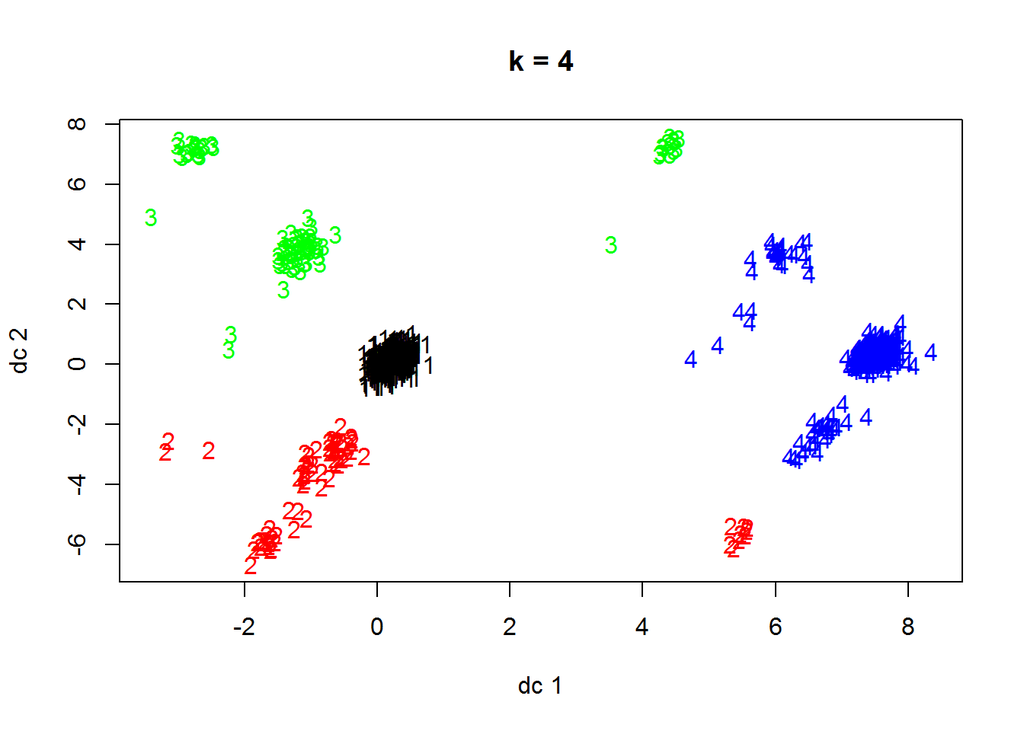

```r
library(fpc)
plotcluster(bakery, bakery_clusters_4$cluster, main="k = 4")
```

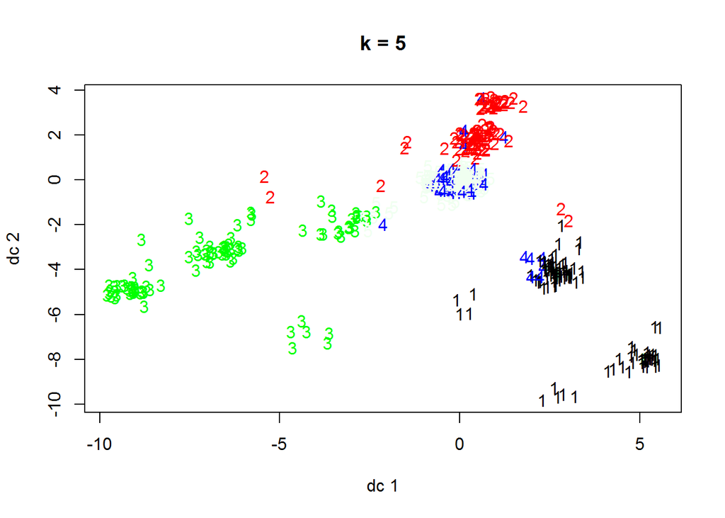

```r
plotcluster(bakery, bakery_clusters_5$cluster, main="k = 5")
```

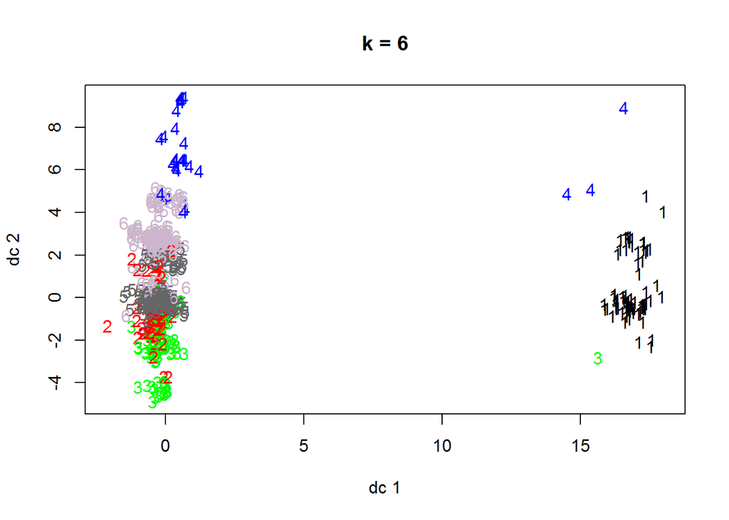

```r
plotcluster(bakery, bakery_clusters_6$cluster, main="k = 6")
```

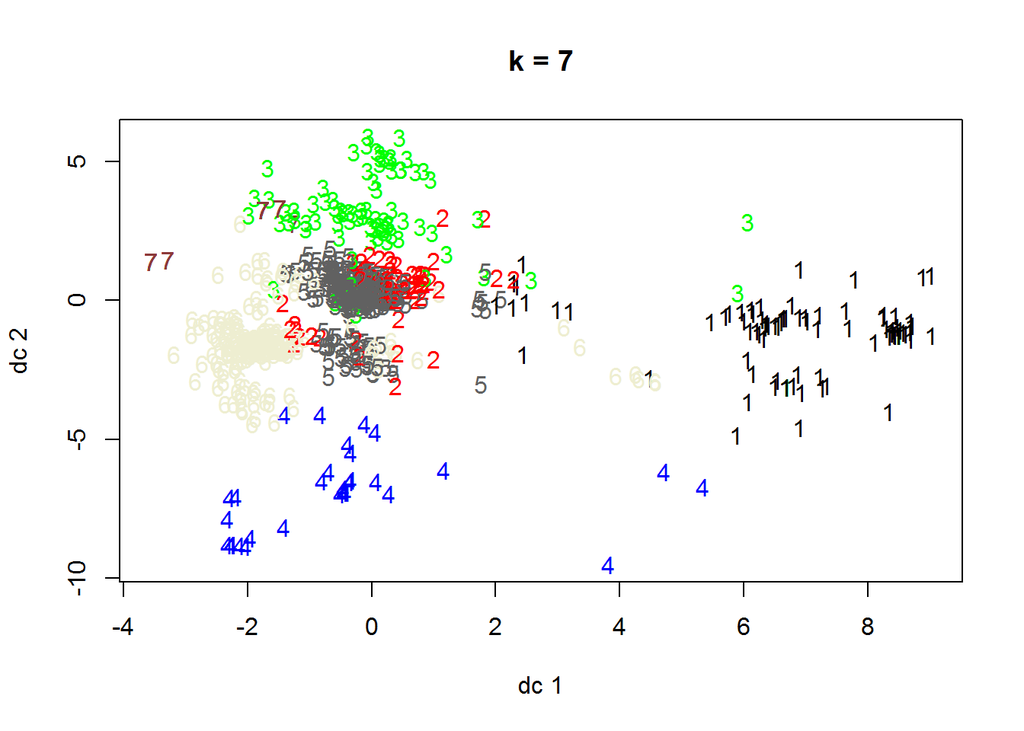

```r
plotcluster(bakery, bakery_clusters_7$cluster, main="k = 7")
```

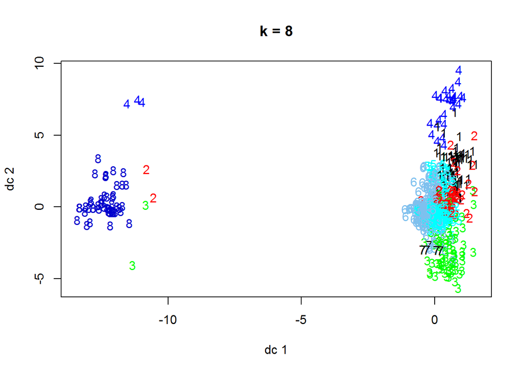

```r
plotcluster(bakery, bakery_clusters_8$cluster, main="k = 8")
```

#### Method 2: Examine the betweenss and withinss ratios.

```r
# Within Sum of Squares
bakery_clusters_4$withinss
```

```
## [1] 1657.5093  231.2439  285.8022  940.5979
```

```r
# Between Sum of Squares
bakery_clusters_4$betweenss
```

```
## [1] 368.8236
```

```r
# Total Sum of Squares
bakery_clusters_4$totss
```

```
## [1] 3483.977
```

```r
bakery_clusters_5$withinss
```

```
## [1]  346.5593  303.0874  311.0693  378.4769 1750.2208
```

```r
bakery_clusters_5$betweenss
```

```
## [1] 394.5633
```

```r
bakery_clusters_5$totss
```

```
## [1] 3483.977
```

```r
bakery_clusters_6$withinss
```

```
## [1]  221.90805  211.66667  255.65476   72.04082 1367.28855  796.62097
```

```r
bakery_clusters_6$betweenss
```

```
## [1] 558.7972
```

```r
bakery_clusters_6$totss
```

```
## [1] 3483.977
```

```r
bakery_clusters_7$withinss
```

```
## [1]  230.68182  201.85526  268.89655   72.04082 1238.65566  787.09312
## [7]   14.27586
```

```r
bakery_clusters_7$betweenss
```

```
## [1] 670.4779
```

```r
bakery_clusters_7$totss
```

```
## [1] 3483.977
```

```r
bakery_clusters_8$withinss
```

```
## [1]  240.04494  201.60000  244.96386   72.04082 1139.76826  696.66518
## [7]   14.27586  157.53704
```

```r
bakery_clusters_8$betweenss
```

```
## [1] 717.081
```

```r
bakery_clusters_8$totss
```

```
## [1] 3483.977
```

Separation is determined by between sum of square / total sum of square  
k = 8 has the highest between sum of square which means most separation.

```r
clusters4<- bakery_clusters_4$betweenss/bakery_clusters_4$totss
clusters5<- bakery_clusters_5$betweenss/bakery_clusters_5$totss
clusters6<- bakery_clusters_6$betweenss/bakery_clusters_6$totss
clusters7<- bakery_clusters_7$betweenss/bakery_clusters_7$totss
clusters8<- bakery_clusters_8$betweenss/bakery_clusters_8$totss

betweenss.metric <- c(clusters4, clusters5, clusters6, clusters7, clusters8)
print(betweenss.metric) # Look for a ratio that is closer to 1.
```

```
## [1] 0.1058628 0.1132508 0.1603906 0.1924461 0.2058226
```

Cluster Cohesion within sum of square / total sum of square ratio k = 8 has the lowest within sum of square which means most cohesion.

```r
clusters4<- bakery_clusters_4$tot.withinss/bakery_clusters_5$totss
clusters5<- bakery_clusters_5$tot.withinss/bakery_clusters_5$totss
clusters6<- bakery_clusters_6$tot.withinss/bakery_clusters_6$totss
clusters7<- bakery_clusters_7$tot.withinss/bakery_clusters_7$totss
clusters8<- bakery_clusters_8$tot.withinss/bakery_clusters_8$totss

totwithinss.metric <- c(clusters4, clusters5, clusters6, clusters7, clusters8)
print(totwithinss.metric) #Looking for a ratio that is closer to 0.
```

```
## [1] 0.8941372 0.8867492 0.8396094 0.8075539 0.7941774
```

#### Method 3: Using the “Elbow Method”

##### Within Sum of Squares

elbow point at K = 5, 7

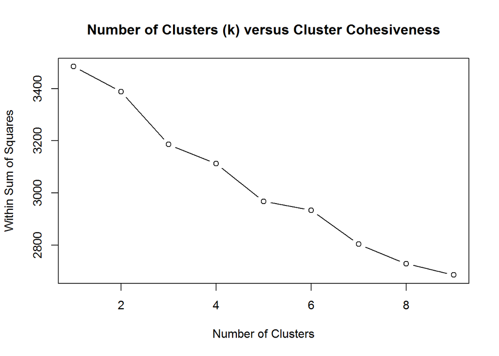

```r
# for one cluster the withiness is equals to 3483 (sum of variance on all items).
wss <- NULL
wss[1] <- (nrow(bakery)-1)*sum(apply(bakery, 2, var))
# test within ss from 2 to 8 clusters.
# elbow point at K = 5, 7
set.seed(123)
for (i in 1:9)
  wss[i] <- sum(kmeans(bakery, centers=i)$withinss)

plot(1:9, wss, type="b", xlab="Number of Clusters", ylab="Within Sum of Squares",
     main = "Number of Clusters (k) versus Cluster Cohesiveness")
```

##### Between sum of square elbow point at K= 4, 6

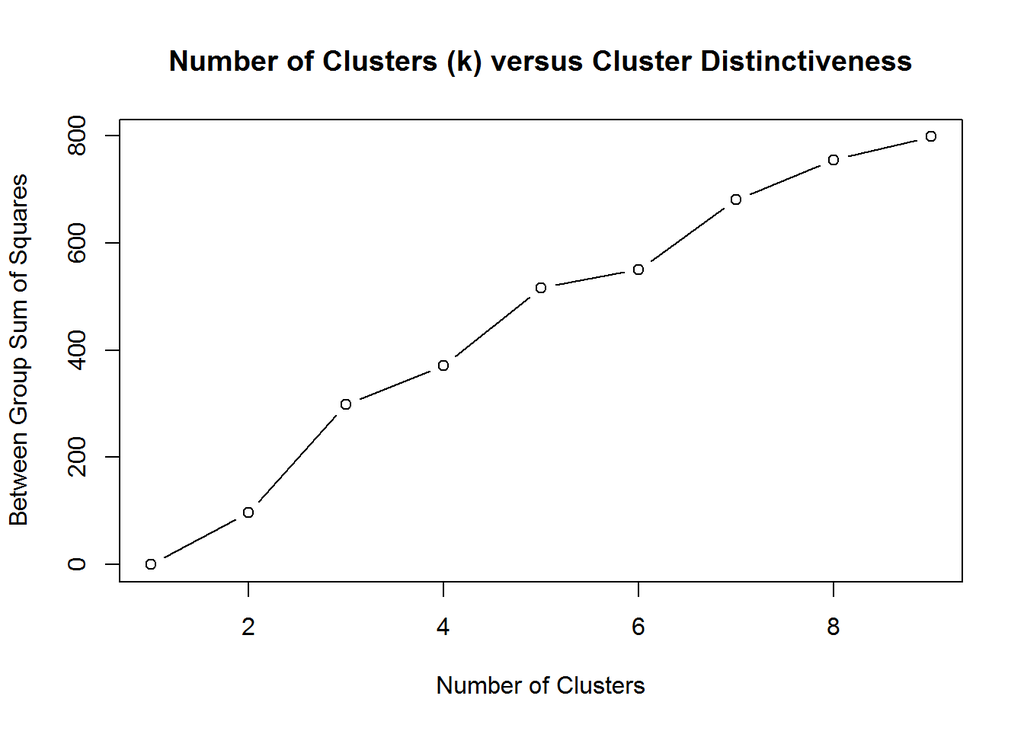

```r
bss <- NULL
bss[1] <- (nrow(bakery)-1)*sum(apply(bakery, 2, var))
set.seed(123)
for (i in 1:9)
  bss[i] <- sum(kmeans(bakery, centers=i)$betweenss)
plot(1:9, bss, type="b", xlab="Number of Clusters",
     ylab="Between Group Sum of Squares", main = "Number of Clusters (k) versus Cluster Distinctiveness")
```

#### Method 4: Using pseudo-F statistic

K = 7 has largest pseudo F-statistic

```r
library(clusterSim)
#help(index.G1) #read the ../doc/indexG1_details.pdf

a<-index.G1(bakery, bakery_clusters_4$cluster, centrotypes = "centroids")
b<-index.G1(bakery, bakery_clusters_5$cluster, centrotypes = "centroids")
c<-index.G1(bakery, bakery_clusters_6$cluster, centrotypes = "centroids")
d<-index.G1(bakery, bakery_clusters_7$cluster, centrotypes = "centroids")
e<-index.G1(bakery, bakery_clusters_8$cluster, centrotypes = "centroids")

pseudoF<-c(a,b,c,d,e)
pseudoF
```

```
## [1] 39.30768 31.76901 37.97677 39.43989 36.72730
```

FPC library suggest K = 4 kmeansruns also use pseudo-F statistic

```r
library(fpc)
bakery_clusters_optimal<-kmeansruns(bakery, krange=4:8) #finds the "best"" K between 4 and 8
bakery_clusters_optimal$bestk
```

```
## [1] 4
```

### Creating an Aggregate Profile for Our Clusters

```r
bakery_clusters_7$size #Get the size of each cluster
```

```
## [1]  88  76  87  49 424 247  29
```

```r
Clusters_7<-data.frame(t(bakery_clusters_7$centers)) #Transpose for easier reading
Clusters_7
```

```
##                             X1         X2         X3         X4
## Chocolate.Cake      0.02272727 0.05263158 0.06896552 0.00000000
## Lemon.Cake          0.01136364 0.76315789 0.03448276 0.04081633
## Casino.Cake         0.04545455 0.10526316 0.06896552 0.02040816
## Opera.Cake          0.04545455 0.02631579 0.04597701 0.83673469
## Strawberry.Cake     0.89772727 0.00000000 0.02298851 0.06122449
## Truffle.Cake        0.06818182 0.06578947 0.17241379 0.02040816
## Chocolate.Eclair    0.03409091 0.05263158 0.03448276 0.04081633
## Coffee.Eclair       0.06818182 0.00000000 0.03448276 0.00000000
## Vanilla.Eclair      0.02272727 0.10526316 0.04597701 0.02040816
## Napoleon.Cake       0.65909091 0.02631579 0.04597701 0.04081633
## Almond.Tart         0.07954545 0.03947368 0.04597701 0.04081633
## Apple.Pie           0.03409091 0.03947368 0.03448276 0.04081633
## Apple.Tart          0.09090909 0.02631579 0.02298851 0.00000000
## Apricot.Tart        0.10227273 0.05263158 0.04597701 0.00000000
## Berry.Tart          0.11363636 0.07894737 0.04597701 0.04081633
## Blackberry.Tart     0.09090909 0.03947368 0.03448276 0.02040816
## Blueberry.Tart      0.03409091 0.06578947 0.06896552 0.00000000
## Chocolate.Tart      0.05681818 0.05263158 0.02298851 0.00000000
## Cherry.Tart         0.04545455 0.02631579 0.03448276 1.00000000
## Lemon.Tart          0.04545455 0.75000000 0.02298851 0.02040816
## Pecan.Tart          0.02272727 0.03947368 0.05747126 0.02040816
## Ganache.Cookie      0.09090909 0.03947368 0.09195402 0.02040816
## Gongolais.Cookie    0.01136364 0.03947368 0.13793103 0.06122449
## Raspberry.Cookie    0.02272727 0.06578947 0.16091954 0.00000000
## Lemon.Cookie        0.05681818 0.03947368 0.04597701 0.02040816
## Chocolate.Meringue  0.06818182 0.07894737 0.04597701 0.00000000
## Vanilla.Meringue    0.02272727 0.07894737 0.03448276 0.00000000
## Marzipan.Cookie     0.02272727 0.05263158 0.12643678 0.02040816
## Tuile.Cookie        0.03409091 0.06578947 0.08045977 0.02040816
## Walnut.Cookie       0.02272727 0.03947368 0.04597701 0.06122449
## Almond.Croissant    0.02272727 0.10526316 0.02298851 0.00000000
## Apple.Croissant     0.04545455 0.05263158 0.06896552 0.02040816
## Apricot.Croissant   0.05681818 0.11842105 0.04597701 0.02040816
## Cheese.Croissant    0.06818182 0.02631579 0.67816092 0.00000000
## Chocolate.Croissant 0.04545455 0.03947368 0.03448276 0.00000000
## Apricot.Danish      0.00000000 0.05263158 0.05747126 0.93877551
## Apple.Danish        0.05681818 0.03947368 0.05747126 0.00000000
## Almond.Twist        0.06818182 0.02631579 0.05747126 0.04081633
## Almond.Bear.Claw    0.01136364 0.03947368 0.03448276 0.02040816
```

[output cut: 49 more lines]

```
## Apple.Danish        0.096698113 0.12145749 0.00000000
## Almond.Twist        0.070754717 0.08097166 0.00000000
## Almond.Bear.Claw    0.021226415 0.03643725 0.00000000
## Blueberry.Danish    0.061320755 0.04048583 0.00000000
## Lemon.Lemonade      0.033018868 0.04453441 0.96551724
## Raspberry.Lemonade  0.033018868 0.05263158 1.00000000
## Orange.Juice        0.000000000 0.06072874 0.00000000
## Green.Tea           0.051886792 0.04453441 0.65517241
## Bottled.Water       0.094339623 0.08097166 0.00000000
## Hot.Coffee          0.120283019 0.10931174 0.00000000
## Chocolate.Coffee    0.096698113 0.10526316 0.00000000
## Vanilla.Frappuccino 0.073113208 0.10121457 0.00000000
## Cherry.Soda         0.103773585 0.08502024 0.00000000
## Single.Espresso     0.082547170 0.06072874 0.00000000
## Weekend             0.000000000 1.00000000 0.27586207
```

### We can sort the centroids for each cluster.

```r
Clusters_7[order(-Clusters_7$X1), ]
```

```
##                             X1         X2         X3         X4
## Strawberry.Cake     0.89772727 0.00000000 0.02298851 0.06122449
## Napoleon.Cake       0.65909091 0.02631579 0.04597701 0.04081633
## Weekend             0.20454545 0.11842105 0.16091954 0.38775510
## Berry.Tart          0.11363636 0.07894737 0.04597701 0.04081633
## Apricot.Tart        0.10227273 0.05263158 0.04597701 0.00000000
## Apple.Tart          0.09090909 0.02631579 0.02298851 0.00000000
## Blackberry.Tart     0.09090909 0.03947368 0.03448276 0.02040816
## Ganache.Cookie      0.09090909 0.03947368 0.09195402 0.02040816
## Almond.Tart         0.07954545 0.03947368 0.04597701 0.04081633
## Vanilla.Frappuccino 0.07954545 0.01315789 0.08045977 0.06122449
## Truffle.Cake        0.06818182 0.06578947 0.17241379 0.02040816
## Coffee.Eclair       0.06818182 0.00000000 0.03448276 0.00000000
## Chocolate.Meringue  0.06818182 0.07894737 0.04597701 0.00000000
## Cheese.Croissant    0.06818182 0.02631579 0.67816092 0.00000000
## Almond.Twist        0.06818182 0.02631579 0.05747126 0.04081633
## Lemon.Lemonade      0.06818182 0.01315789 0.04597701 0.04081633
## Chocolate.Tart      0.05681818 0.05263158 0.02298851 0.00000000
## Lemon.Cookie        0.05681818 0.03947368 0.04597701 0.02040816
## Apricot.Croissant   0.05681818 0.11842105 0.04597701 0.02040816
## Apple.Danish        0.05681818 0.03947368 0.05747126 0.00000000
## Blueberry.Danish    0.05681818 0.05263158 0.09195402 0.04081633
## Green.Tea           0.05681818 0.03947368 0.01149425 0.02040816
## Hot.Coffee          0.05681818 0.03947368 0.05747126 0.06122449
## Chocolate.Coffee    0.05681818 0.05263158 0.09195402 0.02040816
## Casino.Cake         0.04545455 0.10526316 0.06896552 0.02040816
## Opera.Cake          0.04545455 0.02631579 0.04597701 0.83673469
## Cherry.Tart         0.04545455 0.02631579 0.03448276 1.00000000
## Lemon.Tart          0.04545455 0.75000000 0.02298851 0.02040816
## Apple.Croissant     0.04545455 0.05263158 0.06896552 0.02040816
## Chocolate.Croissant 0.04545455 0.03947368 0.03448276 0.00000000
## Bottled.Water       0.04545455 0.07894737 0.06896552 0.02040816
## Cherry.Soda         0.04545455 0.05263158 0.03448276 0.02040816
## Chocolate.Eclair    0.03409091 0.05263158 0.03448276 0.04081633
## Apple.Pie           0.03409091 0.03947368 0.03448276 0.04081633
## Blueberry.Tart      0.03409091 0.06578947 0.06896552 0.00000000
## Tuile.Cookie        0.03409091 0.06578947 0.08045977 0.02040816
## Raspberry.Lemonade  0.03409091 0.05263158 0.08045977 0.04081633
## Chocolate.Cake      0.02272727 0.05263158 0.06896552 0.00000000
## Vanilla.Eclair      0.02272727 0.10526316 0.04597701 0.02040816
```

[output cut: 49 more lines]

```
## Raspberry.Lemonade  0.033018868 0.05263158 1.00000000
## Chocolate.Cake      0.108490566 0.10526316 0.00000000
## Vanilla.Eclair      0.035377358 0.02834008 0.00000000
## Pecan.Tart          0.047169811 0.03643725 0.00000000
## Raspberry.Cookie    0.040094340 0.06072874 1.00000000
## Vanilla.Meringue    0.049528302 0.06072874 0.00000000
## Marzipan.Cookie     0.134433962 0.06072874 0.00000000
## Walnut.Cookie       0.058962264 0.09716599 0.00000000
## Almond.Croissant    0.056603774 0.05263158 0.00000000
## Single.Espresso     0.082547170 0.06072874 0.00000000
## Lemon.Cake          0.002358491 0.08097166 0.00000000
## Gongolais.Cookie    0.141509434 0.11740891 0.00000000
## Almond.Bear.Claw    0.021226415 0.03643725 0.00000000
## Apricot.Danish      0.025943396 0.03643725 0.00000000
## Orange.Juice        0.000000000 0.06072874 0.00000000
```

```r
Clusters_7[order(-Clusters_7$X2), ]
```

```
##                             X1         X2         X3         X4
## Lemon.Cake          0.01136364 0.76315789 0.03448276 0.04081633
## Lemon.Tart          0.04545455 0.75000000 0.02298851 0.02040816
## Apricot.Croissant   0.05681818 0.11842105 0.04597701 0.02040816
## Weekend             0.20454545 0.11842105 0.16091954 0.38775510
## Casino.Cake         0.04545455 0.10526316 0.06896552 0.02040816
## Vanilla.Eclair      0.02272727 0.10526316 0.04597701 0.02040816
## Almond.Croissant    0.02272727 0.10526316 0.02298851 0.00000000
## Berry.Tart          0.11363636 0.07894737 0.04597701 0.04081633
## Chocolate.Meringue  0.06818182 0.07894737 0.04597701 0.00000000
## Vanilla.Meringue    0.02272727 0.07894737 0.03448276 0.00000000
## Bottled.Water       0.04545455 0.07894737 0.06896552 0.02040816
## Truffle.Cake        0.06818182 0.06578947 0.17241379 0.02040816
## Blueberry.Tart      0.03409091 0.06578947 0.06896552 0.00000000
## Raspberry.Cookie    0.02272727 0.06578947 0.16091954 0.00000000
## Tuile.Cookie        0.03409091 0.06578947 0.08045977 0.02040816
## Chocolate.Cake      0.02272727 0.05263158 0.06896552 0.00000000
## Chocolate.Eclair    0.03409091 0.05263158 0.03448276 0.04081633
## Apricot.Tart        0.10227273 0.05263158 0.04597701 0.00000000
## Chocolate.Tart      0.05681818 0.05263158 0.02298851 0.00000000
## Marzipan.Cookie     0.02272727 0.05263158 0.12643678 0.02040816
## Apple.Croissant     0.04545455 0.05263158 0.06896552 0.02040816
## Apricot.Danish      0.00000000 0.05263158 0.05747126 0.93877551
## Blueberry.Danish    0.05681818 0.05263158 0.09195402 0.04081633
## Raspberry.Lemonade  0.03409091 0.05263158 0.08045977 0.04081633
## Chocolate.Coffee    0.05681818 0.05263158 0.09195402 0.02040816
## Cherry.Soda         0.04545455 0.05263158 0.03448276 0.02040816
## Almond.Tart         0.07954545 0.03947368 0.04597701 0.04081633
## Apple.Pie           0.03409091 0.03947368 0.03448276 0.04081633
## Blackberry.Tart     0.09090909 0.03947368 0.03448276 0.02040816
## Pecan.Tart          0.02272727 0.03947368 0.05747126 0.02040816
## Ganache.Cookie      0.09090909 0.03947368 0.09195402 0.02040816
## Gongolais.Cookie    0.01136364 0.03947368 0.13793103 0.06122449
## Lemon.Cookie        0.05681818 0.03947368 0.04597701 0.02040816
## Walnut.Cookie       0.02272727 0.03947368 0.04597701 0.06122449
## Chocolate.Croissant 0.04545455 0.03947368 0.03448276 0.00000000
## Apple.Danish        0.05681818 0.03947368 0.05747126 0.00000000
## Almond.Bear.Claw    0.01136364 0.03947368 0.03448276 0.02040816
## Green.Tea           0.05681818 0.03947368 0.01149425 0.02040816
## Hot.Coffee          0.05681818 0.03947368 0.05747126 0.06122449
```

[output cut: 49 more lines]

```
## Almond.Bear.Claw    0.021226415 0.03643725 0.00000000
## Green.Tea           0.051886792 0.04453441 0.65517241
## Hot.Coffee          0.120283019 0.10931174 0.00000000
## Opera.Cake          0.028301887 0.06072874 0.00000000
## Napoleon.Cake       0.016509434 0.06882591 0.00000000
## Apple.Tart          0.103773585 0.09311741 0.00000000
## Cherry.Tart         0.040094340 0.03643725 0.00000000
## Cheese.Croissant    0.000000000 0.04453441 0.00000000
## Almond.Twist        0.070754717 0.08097166 0.00000000
## Single.Espresso     0.082547170 0.06072874 0.00000000
## Lemon.Lemonade      0.033018868 0.04453441 0.96551724
## Orange.Juice        0.000000000 0.06072874 0.00000000
## Vanilla.Frappuccino 0.073113208 0.10121457 0.00000000
## Strawberry.Cake     0.000000000 0.02834008 0.00000000
## Coffee.Eclair       0.122641509 0.12955466 0.00000000
```

```r
Clusters_7[order(-Clusters_7$X3), ]
```

```
##                             X1         X2         X3         X4
## Orange.Juice        0.00000000 0.01315789 0.75862069 0.00000000
## Cheese.Croissant    0.06818182 0.02631579 0.67816092 0.00000000
## Truffle.Cake        0.06818182 0.06578947 0.17241379 0.02040816
## Raspberry.Cookie    0.02272727 0.06578947 0.16091954 0.00000000
## Weekend             0.20454545 0.11842105 0.16091954 0.38775510
## Gongolais.Cookie    0.01136364 0.03947368 0.13793103 0.06122449
## Marzipan.Cookie     0.02272727 0.05263158 0.12643678 0.02040816
## Ganache.Cookie      0.09090909 0.03947368 0.09195402 0.02040816
## Blueberry.Danish    0.05681818 0.05263158 0.09195402 0.04081633
## Chocolate.Coffee    0.05681818 0.05263158 0.09195402 0.02040816
## Tuile.Cookie        0.03409091 0.06578947 0.08045977 0.02040816
## Raspberry.Lemonade  0.03409091 0.05263158 0.08045977 0.04081633
## Vanilla.Frappuccino 0.07954545 0.01315789 0.08045977 0.06122449
## Chocolate.Cake      0.02272727 0.05263158 0.06896552 0.00000000
## Casino.Cake         0.04545455 0.10526316 0.06896552 0.02040816
## Blueberry.Tart      0.03409091 0.06578947 0.06896552 0.00000000
## Apple.Croissant     0.04545455 0.05263158 0.06896552 0.02040816
## Bottled.Water       0.04545455 0.07894737 0.06896552 0.02040816
## Pecan.Tart          0.02272727 0.03947368 0.05747126 0.02040816
## Apricot.Danish      0.00000000 0.05263158 0.05747126 0.93877551
## Apple.Danish        0.05681818 0.03947368 0.05747126 0.00000000
## Almond.Twist        0.06818182 0.02631579 0.05747126 0.04081633
## Hot.Coffee          0.05681818 0.03947368 0.05747126 0.06122449
## Opera.Cake          0.04545455 0.02631579 0.04597701 0.83673469
## Vanilla.Eclair      0.02272727 0.10526316 0.04597701 0.02040816
## Napoleon.Cake       0.65909091 0.02631579 0.04597701 0.04081633
## Almond.Tart         0.07954545 0.03947368 0.04597701 0.04081633
## Apricot.Tart        0.10227273 0.05263158 0.04597701 0.00000000
## Berry.Tart          0.11363636 0.07894737 0.04597701 0.04081633
## Lemon.Cookie        0.05681818 0.03947368 0.04597701 0.02040816
## Chocolate.Meringue  0.06818182 0.07894737 0.04597701 0.00000000
## Walnut.Cookie       0.02272727 0.03947368 0.04597701 0.06122449
## Apricot.Croissant   0.05681818 0.11842105 0.04597701 0.02040816
## Lemon.Lemonade      0.06818182 0.01315789 0.04597701 0.04081633
## Single.Espresso     0.02272727 0.02631579 0.04597701 0.02040816
## Lemon.Cake          0.01136364 0.76315789 0.03448276 0.04081633
## Chocolate.Eclair    0.03409091 0.05263158 0.03448276 0.04081633
## Coffee.Eclair       0.06818182 0.00000000 0.03448276 0.00000000
## Apple.Pie           0.03409091 0.03947368 0.03448276 0.04081633
```

[output cut: 49 more lines]

```
## Chocolate.Eclair    0.021226415 0.05263158 0.00000000
## Coffee.Eclair       0.122641509 0.12955466 0.00000000
## Apple.Pie           0.068396226 0.11336032 0.00000000
## Blackberry.Tart     0.084905660 0.08906883 0.00000000
## Cherry.Tart         0.040094340 0.03643725 0.00000000
## Vanilla.Meringue    0.049528302 0.06072874 0.00000000
## Chocolate.Croissant 0.058962264 0.02834008 0.00000000
## Almond.Bear.Claw    0.021226415 0.03643725 0.00000000
## Cherry.Soda         0.103773585 0.08502024 0.00000000
## Strawberry.Cake     0.000000000 0.02834008 0.00000000
## Apple.Tart          0.103773585 0.09311741 0.00000000
## Chocolate.Tart      0.054245283 0.06882591 0.00000000
## Lemon.Tart          0.000000000 0.04858300 0.00000000
## Almond.Croissant    0.056603774 0.05263158 0.00000000
## Green.Tea           0.051886792 0.04453441 0.65517241
```

```r
Clusters_7[order(-Clusters_7$X4), ]
```

```
##                             X1         X2         X3         X4
## Cherry.Tart         0.04545455 0.02631579 0.03448276 1.00000000
## Apricot.Danish      0.00000000 0.05263158 0.05747126 0.93877551
## Opera.Cake          0.04545455 0.02631579 0.04597701 0.83673469
## Weekend             0.20454545 0.11842105 0.16091954 0.38775510
## Strawberry.Cake     0.89772727 0.00000000 0.02298851 0.06122449
## Gongolais.Cookie    0.01136364 0.03947368 0.13793103 0.06122449
## Walnut.Cookie       0.02272727 0.03947368 0.04597701 0.06122449
## Hot.Coffee          0.05681818 0.03947368 0.05747126 0.06122449
## Vanilla.Frappuccino 0.07954545 0.01315789 0.08045977 0.06122449
## Lemon.Cake          0.01136364 0.76315789 0.03448276 0.04081633
## Chocolate.Eclair    0.03409091 0.05263158 0.03448276 0.04081633
## Napoleon.Cake       0.65909091 0.02631579 0.04597701 0.04081633
## Almond.Tart         0.07954545 0.03947368 0.04597701 0.04081633
## Apple.Pie           0.03409091 0.03947368 0.03448276 0.04081633
## Berry.Tart          0.11363636 0.07894737 0.04597701 0.04081633
## Almond.Twist        0.06818182 0.02631579 0.05747126 0.04081633
## Blueberry.Danish    0.05681818 0.05263158 0.09195402 0.04081633
## Lemon.Lemonade      0.06818182 0.01315789 0.04597701 0.04081633
## Raspberry.Lemonade  0.03409091 0.05263158 0.08045977 0.04081633
## Casino.Cake         0.04545455 0.10526316 0.06896552 0.02040816
## Truffle.Cake        0.06818182 0.06578947 0.17241379 0.02040816
## Vanilla.Eclair      0.02272727 0.10526316 0.04597701 0.02040816
## Blackberry.Tart     0.09090909 0.03947368 0.03448276 0.02040816
## Lemon.Tart          0.04545455 0.75000000 0.02298851 0.02040816
## Pecan.Tart          0.02272727 0.03947368 0.05747126 0.02040816
## Ganache.Cookie      0.09090909 0.03947368 0.09195402 0.02040816
## Lemon.Cookie        0.05681818 0.03947368 0.04597701 0.02040816
## Marzipan.Cookie     0.02272727 0.05263158 0.12643678 0.02040816
## Tuile.Cookie        0.03409091 0.06578947 0.08045977 0.02040816
## Apple.Croissant     0.04545455 0.05263158 0.06896552 0.02040816
## Apricot.Croissant   0.05681818 0.11842105 0.04597701 0.02040816
## Almond.Bear.Claw    0.01136364 0.03947368 0.03448276 0.02040816
## Green.Tea           0.05681818 0.03947368 0.01149425 0.02040816
## Bottled.Water       0.04545455 0.07894737 0.06896552 0.02040816
## Chocolate.Coffee    0.05681818 0.05263158 0.09195402 0.02040816
## Cherry.Soda         0.04545455 0.05263158 0.03448276 0.02040816
## Single.Espresso     0.02272727 0.02631579 0.04597701 0.02040816
## Chocolate.Cake      0.02272727 0.05263158 0.06896552 0.00000000
## Coffee.Eclair       0.06818182 0.00000000 0.03448276 0.00000000
```

[output cut: 49 more lines]

```
## Single.Espresso     0.082547170 0.06072874 0.00000000
## Chocolate.Cake      0.108490566 0.10526316 0.00000000
## Coffee.Eclair       0.122641509 0.12955466 0.00000000
## Apple.Tart          0.103773585 0.09311741 0.00000000
## Apricot.Tart        0.044811321 0.07692308 0.03448276
## Blueberry.Tart      0.115566038 0.07287449 0.00000000
## Chocolate.Tart      0.054245283 0.06882591 0.00000000
## Raspberry.Cookie    0.040094340 0.06072874 1.00000000
## Chocolate.Meringue  0.035377358 0.02834008 0.00000000
## Vanilla.Meringue    0.049528302 0.06072874 0.00000000
## Almond.Croissant    0.056603774 0.05263158 0.00000000
## Cheese.Croissant    0.000000000 0.04453441 0.00000000
## Chocolate.Croissant 0.058962264 0.02834008 0.00000000
## Apple.Danish        0.096698113 0.12145749 0.00000000
## Orange.Juice        0.000000000 0.06072874 0.00000000
```

```r
Clusters_7[order(-Clusters_7$X5), ]
```

```
##                             X1         X2         X3         X4
## Gongolais.Cookie    0.01136364 0.03947368 0.13793103 0.06122449
## Tuile.Cookie        0.03409091 0.06578947 0.08045977 0.02040816
## Marzipan.Cookie     0.02272727 0.05263158 0.12643678 0.02040816
## Truffle.Cake        0.06818182 0.06578947 0.17241379 0.02040816
## Coffee.Eclair       0.06818182 0.00000000 0.03448276 0.00000000
## Hot.Coffee          0.05681818 0.03947368 0.05747126 0.06122449
## Blueberry.Tart      0.03409091 0.06578947 0.06896552 0.00000000
## Apple.Croissant     0.04545455 0.05263158 0.06896552 0.02040816
## Chocolate.Cake      0.02272727 0.05263158 0.06896552 0.00000000
## Apple.Tart          0.09090909 0.02631579 0.02298851 0.00000000
## Cherry.Soda         0.04545455 0.05263158 0.03448276 0.02040816
## Berry.Tart          0.11363636 0.07894737 0.04597701 0.04081633
## Apple.Danish        0.05681818 0.03947368 0.05747126 0.00000000
## Chocolate.Coffee    0.05681818 0.05263158 0.09195402 0.02040816
## Apricot.Croissant   0.05681818 0.11842105 0.04597701 0.02040816
## Bottled.Water       0.04545455 0.07894737 0.06896552 0.02040816
## Blackberry.Tart     0.09090909 0.03947368 0.03448276 0.02040816
## Single.Espresso     0.02272727 0.02631579 0.04597701 0.02040816
## Casino.Cake         0.04545455 0.10526316 0.06896552 0.02040816
## Vanilla.Frappuccino 0.07954545 0.01315789 0.08045977 0.06122449
## Almond.Twist        0.06818182 0.02631579 0.05747126 0.04081633
## Apple.Pie           0.03409091 0.03947368 0.03448276 0.04081633
## Blueberry.Danish    0.05681818 0.05263158 0.09195402 0.04081633
## Walnut.Cookie       0.02272727 0.03947368 0.04597701 0.06122449
## Chocolate.Croissant 0.04545455 0.03947368 0.03448276 0.00000000
## Almond.Croissant    0.02272727 0.10526316 0.02298851 0.00000000
## Chocolate.Tart      0.05681818 0.05263158 0.02298851 0.00000000
## Green.Tea           0.05681818 0.03947368 0.01149425 0.02040816
## Vanilla.Meringue    0.02272727 0.07894737 0.03448276 0.00000000
## Almond.Tart         0.07954545 0.03947368 0.04597701 0.04081633
## Pecan.Tart          0.02272727 0.03947368 0.05747126 0.02040816
## Apricot.Tart        0.10227273 0.05263158 0.04597701 0.00000000
## Lemon.Cookie        0.05681818 0.03947368 0.04597701 0.02040816
## Cherry.Tart         0.04545455 0.02631579 0.03448276 1.00000000
## Raspberry.Cookie    0.02272727 0.06578947 0.16091954 0.00000000
## Vanilla.Eclair      0.02272727 0.10526316 0.04597701 0.02040816
## Chocolate.Meringue  0.06818182 0.07894737 0.04597701 0.00000000
## Lemon.Lemonade      0.06818182 0.01315789 0.04597701 0.04081633
## Raspberry.Lemonade  0.03409091 0.05263158 0.08045977 0.04081633
```

[output cut: 49 more lines]

```
## Chocolate.Meringue  0.035377358 0.02834008 0.00000000
## Lemon.Lemonade      0.033018868 0.04453441 0.96551724
## Raspberry.Lemonade  0.033018868 0.05263158 1.00000000
## Ganache.Cookie      0.030660377 0.04453441 0.00000000
## Opera.Cake          0.028301887 0.06072874 0.00000000
## Apricot.Danish      0.025943396 0.03643725 0.00000000
## Chocolate.Eclair    0.021226415 0.05263158 0.00000000
## Almond.Bear.Claw    0.021226415 0.03643725 0.00000000
## Napoleon.Cake       0.016509434 0.06882591 0.00000000
## Lemon.Cake          0.002358491 0.08097166 0.00000000
## Strawberry.Cake     0.000000000 0.02834008 0.00000000
## Lemon.Tart          0.000000000 0.04858300 0.00000000
## Cheese.Croissant    0.000000000 0.04453441 0.00000000
## Orange.Juice        0.000000000 0.06072874 0.00000000
## Weekend             0.000000000 1.00000000 0.27586207
```

```r
Clusters_7[order(-Clusters_7$X6), ]
```

```
##                             X1         X2         X3         X4
## Weekend             0.20454545 0.11842105 0.16091954 0.38775510
## Coffee.Eclair       0.06818182 0.00000000 0.03448276 0.00000000
## Berry.Tart          0.11363636 0.07894737 0.04597701 0.04081633
## Apple.Danish        0.05681818 0.03947368 0.05747126 0.00000000
## Gongolais.Cookie    0.01136364 0.03947368 0.13793103 0.06122449
## Apple.Pie           0.03409091 0.03947368 0.03448276 0.04081633
## Apple.Croissant     0.04545455 0.05263158 0.06896552 0.02040816
## Hot.Coffee          0.05681818 0.03947368 0.05747126 0.06122449
## Chocolate.Cake      0.02272727 0.05263158 0.06896552 0.00000000
## Tuile.Cookie        0.03409091 0.06578947 0.08045977 0.02040816
## Chocolate.Coffee    0.05681818 0.05263158 0.09195402 0.02040816
## Vanilla.Frappuccino 0.07954545 0.01315789 0.08045977 0.06122449
## Truffle.Cake        0.06818182 0.06578947 0.17241379 0.02040816
## Walnut.Cookie       0.02272727 0.03947368 0.04597701 0.06122449
## Apple.Tart          0.09090909 0.02631579 0.02298851 0.00000000
## Blackberry.Tart     0.09090909 0.03947368 0.03448276 0.02040816
## Casino.Cake         0.04545455 0.10526316 0.06896552 0.02040816
## Cherry.Soda         0.04545455 0.05263158 0.03448276 0.02040816
## Lemon.Cake          0.01136364 0.76315789 0.03448276 0.04081633
## Almond.Twist        0.06818182 0.02631579 0.05747126 0.04081633
## Bottled.Water       0.04545455 0.07894737 0.06896552 0.02040816
## Apricot.Tart        0.10227273 0.05263158 0.04597701 0.00000000
## Blueberry.Tart      0.03409091 0.06578947 0.06896552 0.00000000
## Napoleon.Cake       0.65909091 0.02631579 0.04597701 0.04081633
## Chocolate.Tart      0.05681818 0.05263158 0.02298851 0.00000000
## Apricot.Croissant   0.05681818 0.11842105 0.04597701 0.02040816
## Opera.Cake          0.04545455 0.02631579 0.04597701 0.83673469
## Raspberry.Cookie    0.02272727 0.06578947 0.16091954 0.00000000
## Vanilla.Meringue    0.02272727 0.07894737 0.03448276 0.00000000
## Marzipan.Cookie     0.02272727 0.05263158 0.12643678 0.02040816
## Orange.Juice        0.00000000 0.01315789 0.75862069 0.00000000
## Single.Espresso     0.02272727 0.02631579 0.04597701 0.02040816
## Chocolate.Eclair    0.03409091 0.05263158 0.03448276 0.04081633
## Almond.Croissant    0.02272727 0.10526316 0.02298851 0.00000000
## Raspberry.Lemonade  0.03409091 0.05263158 0.08045977 0.04081633
## Lemon.Tart          0.04545455 0.75000000 0.02298851 0.02040816
## Ganache.Cookie      0.09090909 0.03947368 0.09195402 0.02040816
## Cheese.Croissant    0.06818182 0.02631579 0.67816092 0.00000000
## Lemon.Lemonade      0.06818182 0.01315789 0.04597701 0.04081633
```

[output cut: 49 more lines]

```
## Ganache.Cookie      0.030660377 0.04453441 0.00000000
## Cheese.Croissant    0.000000000 0.04453441 0.00000000
## Lemon.Lemonade      0.033018868 0.04453441 0.96551724
## Green.Tea           0.051886792 0.04453441 0.65517241
## Blueberry.Danish    0.061320755 0.04048583 0.00000000
## Cherry.Tart         0.040094340 0.03643725 0.00000000
## Pecan.Tart          0.047169811 0.03643725 0.00000000
## Apricot.Danish      0.025943396 0.03643725 0.00000000
## Almond.Bear.Claw    0.021226415 0.03643725 0.00000000
## Strawberry.Cake     0.000000000 0.02834008 0.00000000
## Vanilla.Eclair      0.035377358 0.02834008 0.00000000
## Chocolate.Meringue  0.035377358 0.02834008 0.00000000
## Chocolate.Croissant 0.058962264 0.02834008 0.00000000
## Almond.Tart         0.047169811 0.02024291 0.00000000
## Lemon.Cookie        0.044811321 0.02024291 1.00000000
```

```r
Clusters_7[order(-Clusters_7$X7), ]
```

```
##                             X1         X2         X3         X4
## Raspberry.Cookie    0.02272727 0.06578947 0.16091954 0.00000000
## Lemon.Cookie        0.05681818 0.03947368 0.04597701 0.02040816
## Raspberry.Lemonade  0.03409091 0.05263158 0.08045977 0.04081633
## Lemon.Lemonade      0.06818182 0.01315789 0.04597701 0.04081633
## Green.Tea           0.05681818 0.03947368 0.01149425 0.02040816
## Weekend             0.20454545 0.11842105 0.16091954 0.38775510
## Apricot.Tart        0.10227273 0.05263158 0.04597701 0.00000000
## Chocolate.Cake      0.02272727 0.05263158 0.06896552 0.00000000
## Lemon.Cake          0.01136364 0.76315789 0.03448276 0.04081633
## Casino.Cake         0.04545455 0.10526316 0.06896552 0.02040816
## Opera.Cake          0.04545455 0.02631579 0.04597701 0.83673469
## Strawberry.Cake     0.89772727 0.00000000 0.02298851 0.06122449
## Truffle.Cake        0.06818182 0.06578947 0.17241379 0.02040816
## Chocolate.Eclair    0.03409091 0.05263158 0.03448276 0.04081633
## Coffee.Eclair       0.06818182 0.00000000 0.03448276 0.00000000
## Vanilla.Eclair      0.02272727 0.10526316 0.04597701 0.02040816
## Napoleon.Cake       0.65909091 0.02631579 0.04597701 0.04081633
## Almond.Tart         0.07954545 0.03947368 0.04597701 0.04081633
## Apple.Pie           0.03409091 0.03947368 0.03448276 0.04081633
## Apple.Tart          0.09090909 0.02631579 0.02298851 0.00000000
## Berry.Tart          0.11363636 0.07894737 0.04597701 0.04081633
## Blackberry.Tart     0.09090909 0.03947368 0.03448276 0.02040816
## Blueberry.Tart      0.03409091 0.06578947 0.06896552 0.00000000
## Chocolate.Tart      0.05681818 0.05263158 0.02298851 0.00000000
## Cherry.Tart         0.04545455 0.02631579 0.03448276 1.00000000
## Lemon.Tart          0.04545455 0.75000000 0.02298851 0.02040816
## Pecan.Tart          0.02272727 0.03947368 0.05747126 0.02040816
## Ganache.Cookie      0.09090909 0.03947368 0.09195402 0.02040816
## Gongolais.Cookie    0.01136364 0.03947368 0.13793103 0.06122449
## Chocolate.Meringue  0.06818182 0.07894737 0.04597701 0.00000000
## Vanilla.Meringue    0.02272727 0.07894737 0.03448276 0.00000000
## Marzipan.Cookie     0.02272727 0.05263158 0.12643678 0.02040816
## Tuile.Cookie        0.03409091 0.06578947 0.08045977 0.02040816
## Walnut.Cookie       0.02272727 0.03947368 0.04597701 0.06122449
## Almond.Croissant    0.02272727 0.10526316 0.02298851 0.00000000
## Apple.Croissant     0.04545455 0.05263158 0.06896552 0.02040816
## Apricot.Croissant   0.05681818 0.11842105 0.04597701 0.02040816
## Cheese.Croissant    0.06818182 0.02631579 0.67816092 0.00000000
## Chocolate.Croissant 0.04545455 0.03947368 0.03448276 0.00000000
```

[output cut: 49 more lines]

```
## Apricot.Croissant   0.094339623 0.06882591 0.00000000
## Cheese.Croissant    0.000000000 0.04453441 0.00000000
## Chocolate.Croissant 0.058962264 0.02834008 0.00000000
## Apricot.Danish      0.025943396 0.03643725 0.00000000
## Apple.Danish        0.096698113 0.12145749 0.00000000
## Almond.Twist        0.070754717 0.08097166 0.00000000
## Almond.Bear.Claw    0.021226415 0.03643725 0.00000000
## Blueberry.Danish    0.061320755 0.04048583 0.00000000
## Orange.Juice        0.000000000 0.06072874 0.00000000
## Bottled.Water       0.094339623 0.08097166 0.00000000
## Hot.Coffee          0.120283019 0.10931174 0.00000000
## Chocolate.Coffee    0.096698113 0.10526316 0.00000000
## Vanilla.Frappuccino 0.073113208 0.10121457 0.00000000
## Cherry.Soda         0.103773585 0.08502024 0.00000000
## Single.Espresso     0.082547170 0.06072874 0.00000000
```

- **Segment 1 (88)**: High centroid value on Strawberry.Cake, Napoleon.Cake.
- **Segment 2 (76)**: High centroid value on Lemon.Cake, Lemon.Tart.
- **Segment 3 (87)**: High centroid value on Orange.Juice, Cheese.Croissant.
- **Segment 4 (49)**: High centroid value on Cherry.Tart, Apricot.Danish, Opera.Cake.
- **Segment 5 (424)**: All very low centroid values. General basket.
- **Segment 6 (247)**: Weekend 100%. All very low centroid values on all items
- **Segment 7 (29)**: High centroid value on Raspberry.Cookie, Lemon.Cookie, Raspberry.Lemonade, Lemon.Lemonade, Green.Tea.

### We can see item purchased on weekend have low centroid values on all items. What if we only use weekend data.

```r
bakery_weekend <- bakery[which(bakery$Weekend==1),]
dim(bakery_weekend)
```

```
## [1] 315  51
```

```r
summary(bakery_weekend)
```

```
##  Chocolate.Cake      Lemon.Cake       Casino.Cake        Opera.Cake
##  Min.   :0.00000   Min.   :0.00000   Min.   :0.00000   Min.   :0.0000
##  1st Qu.:0.00000   1st Qu.:0.00000   1st Qu.:0.00000   1st Qu.:0.0000
##  Median :0.00000   Median :0.00000   Median :0.00000   Median :0.0000
##  Mean   :0.08889   Mean   :0.09841   Mean   :0.06984   Mean   :0.1016
##  3rd Qu.:0.00000   3rd Qu.:0.00000   3rd Qu.:0.00000   3rd Qu.:0.0000
##  Max.   :1.00000   Max.   :1.00000   Max.   :1.00000   Max.   :1.0000
##  Strawberry.Cake    Truffle.Cake     Chocolate.Eclair  Coffee.Eclair
##  Min.   :0.00000   Min.   :0.00000   Min.   :0.00000   Min.   :0.0000
##  1st Qu.:0.00000   1st Qu.:0.00000   1st Qu.:0.00000   1st Qu.:0.0000
##  Median :0.00000   Median :0.00000   Median :0.00000   Median :0.0000
##  Mean   :0.08254   Mean   :0.08254   Mean   :0.04762   Mean   :0.1016
##  3rd Qu.:0.00000   3rd Qu.:0.00000   3rd Qu.:0.00000   3rd Qu.:0.0000
##  Max.   :1.00000   Max.   :1.00000   Max.   :1.00000   Max.   :1.0000
##  Vanilla.Eclair    Napoleon.Cake     Almond.Tart        Apple.Pie
##  Min.   :0.00000   Min.   :0.0000   Min.   :0.00000   Min.   :0.0000
##  1st Qu.:0.00000   1st Qu.:0.0000   1st Qu.:0.00000   1st Qu.:0.0000
##  Median :0.00000   Median :0.0000   Median :0.00000   Median :0.0000
##  Mean   :0.02857   Mean   :0.1111   Mean   :0.01905   Mean   :0.1016
##  3rd Qu.:0.00000   3rd Qu.:0.0000   3rd Qu.:0.00000   3rd Qu.:0.0000
##  Max.   :1.00000   Max.   :1.0000   Max.   :1.00000   Max.   :1.0000
##    Apple.Tart       Apricot.Tart       Berry.Tart      Blackberry.Tart
##  Min.   :0.00000   Min.   :0.00000   Min.   :0.00000   Min.   :0.00000
##  1st Qu.:0.00000   1st Qu.:0.00000   1st Qu.:0.00000   1st Qu.:0.00000
##  Median :0.00000   Median :0.00000   Median :0.00000   Median :0.00000
##  Mean   :0.08254   Mean   :0.06667   Mean   :0.09841   Mean   :0.07937
##  3rd Qu.:0.00000   3rd Qu.:0.00000   3rd Qu.:0.00000   3rd Qu.:0.00000
##  Max.   :1.00000   Max.   :1.00000   Max.   :1.00000   Max.   :1.00000
##  Blueberry.Tart    Chocolate.Tart     Cherry.Tart        Lemon.Tart
##  Min.   :0.00000   Min.   :0.00000   Min.   :0.00000   Min.   :0.00000
##  1st Qu.:0.00000   1st Qu.:0.00000   1st Qu.:0.00000   1st Qu.:0.00000
##  Median :0.00000   Median :0.00000   Median :0.00000   Median :0.00000
##  Mean   :0.06032   Mean   :0.05714   Mean   :0.09206   Mean   :0.07619
##  3rd Qu.:0.00000   3rd Qu.:0.00000   3rd Qu.:0.00000   3rd Qu.:0.00000
##  Max.   :1.00000   Max.   :1.00000   Max.   :1.00000   Max.   :1.00000
##    Pecan.Tart      Ganache.Cookie    Gongolais.Cookie  Raspberry.Cookie
##  Min.   :0.00000   Min.   :0.00000   Min.   :0.00000   Min.   :0.00000
##  1st Qu.:0.00000   1st Qu.:0.00000   1st Qu.:0.00000   1st Qu.:0.00000
##  Median :0.00000   Median :0.00000   Median :0.00000   Median :0.00000
##  Mean   :0.03492   Mean   :0.04444   Mean   :0.09206   Mean   :0.07937
```

[output cut: 36 more lines]

```
##  Max.   :1.00000   Max.   :1.00000    Max.   :1.00000   Max.   :1.00000
##  Bottled.Water       Hot.Coffee      Chocolate.Coffee  Vanilla.Frappuccino
##  Min.   :0.00000   Min.   :0.00000   Min.   :0.00000   Min.   :0.00000
##  1st Qu.:0.00000   1st Qu.:0.00000   1st Qu.:0.00000   1st Qu.:0.00000
##  Median :0.00000   Median :0.00000   Median :0.00000   Median :0.00000
##  Mean   :0.07302   Mean   :0.09524   Mean   :0.08254   Mean   :0.09524
##  3rd Qu.:0.00000   3rd Qu.:0.00000   3rd Qu.:0.00000   3rd Qu.:0.00000
##  Max.   :1.00000   Max.   :1.00000   Max.   :1.00000   Max.   :1.00000
##   Cherry.Soda      Single.Espresso      Weekend
##  Min.   :0.00000   Min.   :0.00000   Min.   :1
##  1st Qu.:0.00000   1st Qu.:0.00000   1st Qu.:1
##  Median :0.00000   Median :0.00000   Median :1
##  Mean   :0.06667   Mean   :0.04762   Mean   :1
##  3rd Qu.:0.00000   3rd Qu.:0.00000   3rd Qu.:1
##  Max.   :1.00000   Max.   :1.00000   Max.   :1
```

```r
# percent of each items
bakery_weekend_sum <- as.data.frame(apply(bakery_weekend,2,mean))
bakery_weekend_sum
```

```
##                     apply(bakery_weekend, 2, mean)
## Chocolate.Cake                          0.08888889
## Lemon.Cake                              0.09841270
## Casino.Cake                             0.06984127
## Opera.Cake                              0.10158730
## Strawberry.Cake                         0.08253968
## Truffle.Cake                            0.08253968
## Chocolate.Eclair                        0.04761905
## Coffee.Eclair                           0.10158730
## Vanilla.Eclair                          0.02857143
## Napoleon.Cake                           0.11111111
## Almond.Tart                             0.01904762
## Apple.Pie                               0.10158730
## Apple.Tart                              0.08253968
## Apricot.Tart                            0.06666667
## Berry.Tart                              0.09841270
## Blackberry.Tart                         0.07936508
## Blueberry.Tart                          0.06031746
## Chocolate.Tart                          0.05714286
## Cherry.Tart                             0.09206349
## Lemon.Tart                              0.07619048
## Pecan.Tart                              0.03492063
## Ganache.Cookie                          0.04444444
## Gongolais.Cookie                        0.09206349
## Raspberry.Cookie                        0.07936508
## Lemon.Cookie                            0.04444444
## Chocolate.Meringue                      0.02222222
## Vanilla.Meringue                        0.05079365
## Marzipan.Cookie                         0.05079365
## Tuile.Cookie                            0.08253968
## Walnut.Cookie                           0.07936508
## Almond.Croissant                        0.04444444
## Apple.Croissant                         0.09206349
## Apricot.Croissant                       0.06031746
## Cheese.Croissant                        0.08571429
## Chocolate.Croissant                     0.02857143
## Apricot.Danish                          0.09206349
## Apple.Danish                            0.09523810
## Almond.Twist                            0.06666667
## Almond.Bear.Claw                        0.03492063
## Blueberry.Danish                        0.03809524
## Lemon.Lemonade                          0.06984127
## Raspberry.Lemonade                      0.07301587
## Orange.Juice                            0.09206349
## Green.Tea                               0.05079365
## Bottled.Water                           0.07301587
## Hot.Coffee                              0.09523810
## Chocolate.Coffee                        0.08253968
## Vanilla.Frappuccino                     0.09523810
## Cherry.Soda                             0.06666667
## Single.Espresso                         0.04761905
## Weekend                                 1.00000000
```

```r
# 4 clusters
set.seed(123)
bakery_weekend_clusters_4 <- kmeans(bakery_weekend, centers=4)
#t(bakery_weekend_clusters_4$centers)
bakery_weekend_clusters_4$size #Get the size of each cluster
```

```
## [1]  50 219  20  26
```

```r
# 5 clusters
set.seed(123)
bakery_weekend_clusters_5 <- kmeans(bakery_weekend, centers=5)
#t(bakery_weekend_clusters_5$centers)
bakery_weekend_clusters_5$size #Get the size of each cluster
```

```
## [1]  52 174  19  26  44
```

```r
# 6 clusters
set.seed(123)
bakery_weekend_clusters_6 <- kmeans(bakery_weekend, centers=6)
bakery_weekend_clusters_6$size
```

```
## [1]  41 165  19  25  39  26
```

```r
#t(bakery_weekend_clusters_6$centers)
bakery_weekend_clusters_6$size #Get the size of each cluster
```

```
## [1]  41 165  19  25  39  26
```

```r
# 7 clusters
set.seed(123)
bakery_weekend_clusters_7 <- kmeans(bakery_weekend, centers=7)
#t(bakery_weekend_clusters_7$centers)
bakery_weekend_clusters_7$size #Get the size of each cluster
```

```
## [1]  28 162  18  25  38  25  19
```

```r
# 8 clusters
set.seed(123)
bakery_weekend_clusters_8 <- kmeans(bakery_weekend, centers=8)
#t(bakery_weekend_clusters_8$centers)
bakery_weekend_clusters_8$size #Get the size of each cluster
```

```
## [1]  17 169  18  11  43  24  18  15
```